# Project 1

Kat Wiles

Friday, October 24, 2014

### Introduction

When I started on this project, I originally wanted to work with some data from my lab. I struggled with the data processing, which took much more time than expcected. I then got a data set that had already been processed and tried playing around with the package [phyloseq](http://www.plosone.org/article/info%3Adoi%2F10.1371%2Fjournal.pone.0061217). Phyloseq is an R package that is used to visualize microbiome sample data. I had difficulty using the package with the data that I was given. For example, I was trying to make a relative abundance graph and I could not get the code to work.

Instead of continuing with this project, I decided to scrap the whole thing and try to see if I could use the sample data on the [phyloseq website](http://joey711.github.io/phyloseq/) and reproduce many of the figures that are in the tutorial. The phyloseq package is designed to help scientists with reproducible data. I thought it would be interesting to see how reproducible their website is. This will also be useful way of learning how to use phyloseq.

Once I learned how to phyloseq, I played around with the sample data to produce a few new figures and graphs.

### Methods/Results

First I followed the [preprocessing tutorial](http://joey711.github.io/phyloseq/preprocess.html) with the GlobalPatterns data set within phyloseq. In which samples were removed if they were not seen more than 3 times in at least 20 of the samples. I also learned how to subset samples into varying taxonomic levels.

Next, I followed the [richness tutorial](http://joey711.github.io/phyloseq/plot_richness-examples.html). The first figure is plotting the richness of the OTUs in the Global Patterns data set. The graph is showing the different ways to measure alpha diversity. I added in color per sample type (NT) (not in tutorial).

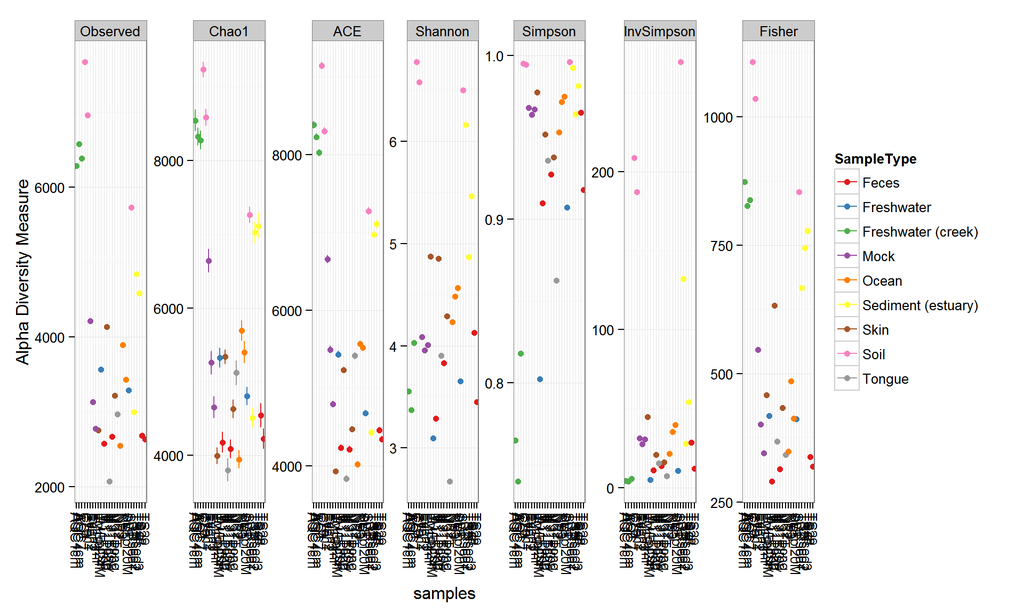

Then, I looked at just the shannon graph (NT).

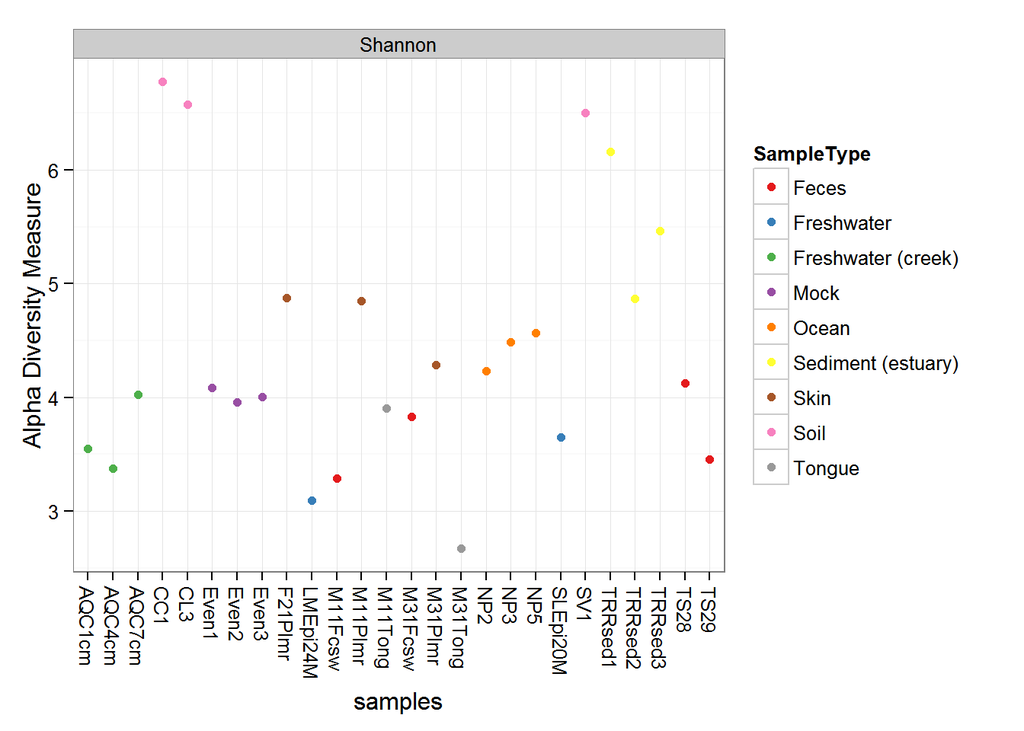

Next I worked through the [ordination tutorial](http://joey711.github.io/phyloseq/plot_ordination-examples.html).

```
## Square root transformation
## Wisconsin double standardization
## ... procrustes: rmse 1.410268e-05  max resid 4.093e-05
## *** Solution reached
```

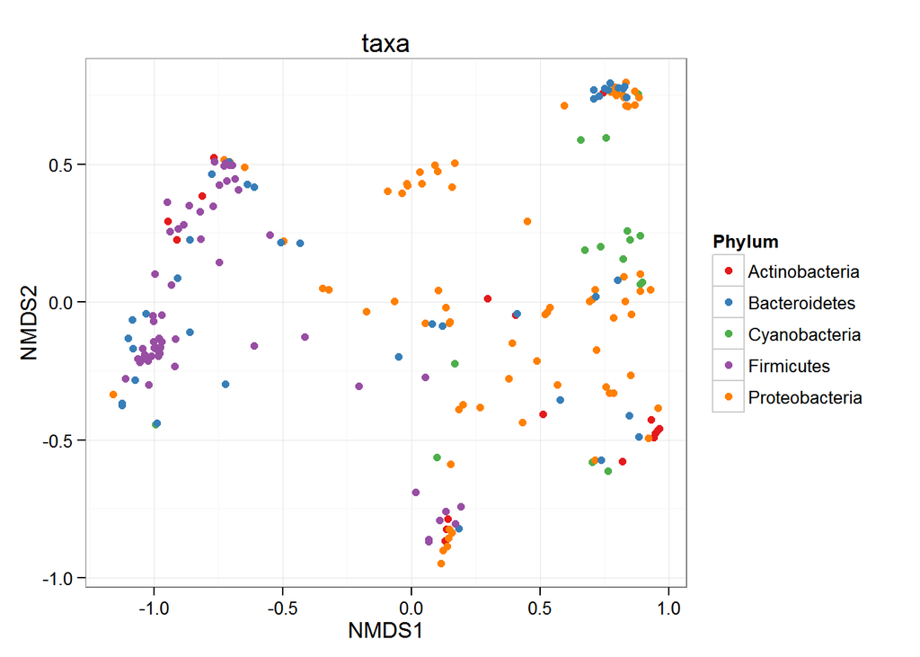

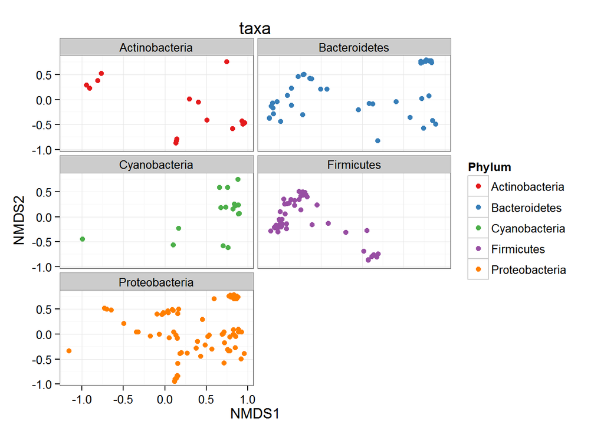

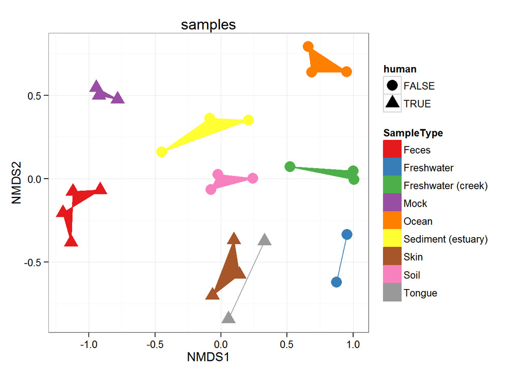

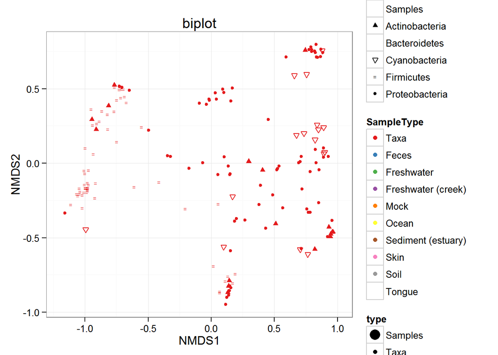

Next I worked with [barplot tutorial](http://joey711.github.io/phyloseq/plot_bar-examples.html) to see if I could recreate the barplots.

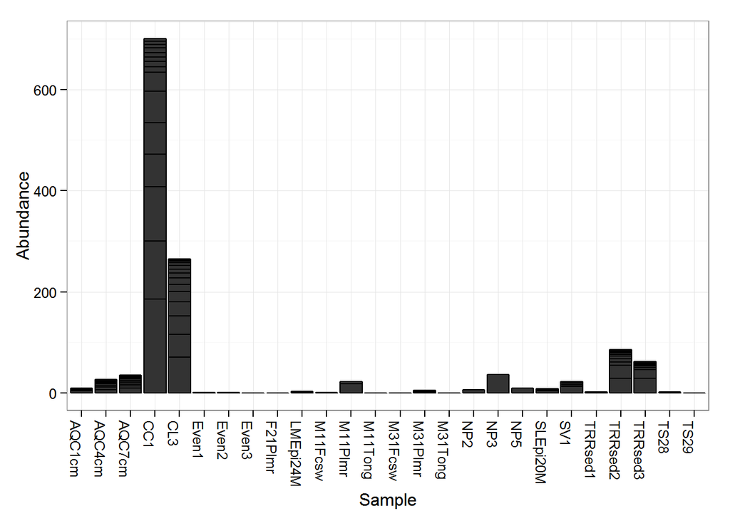

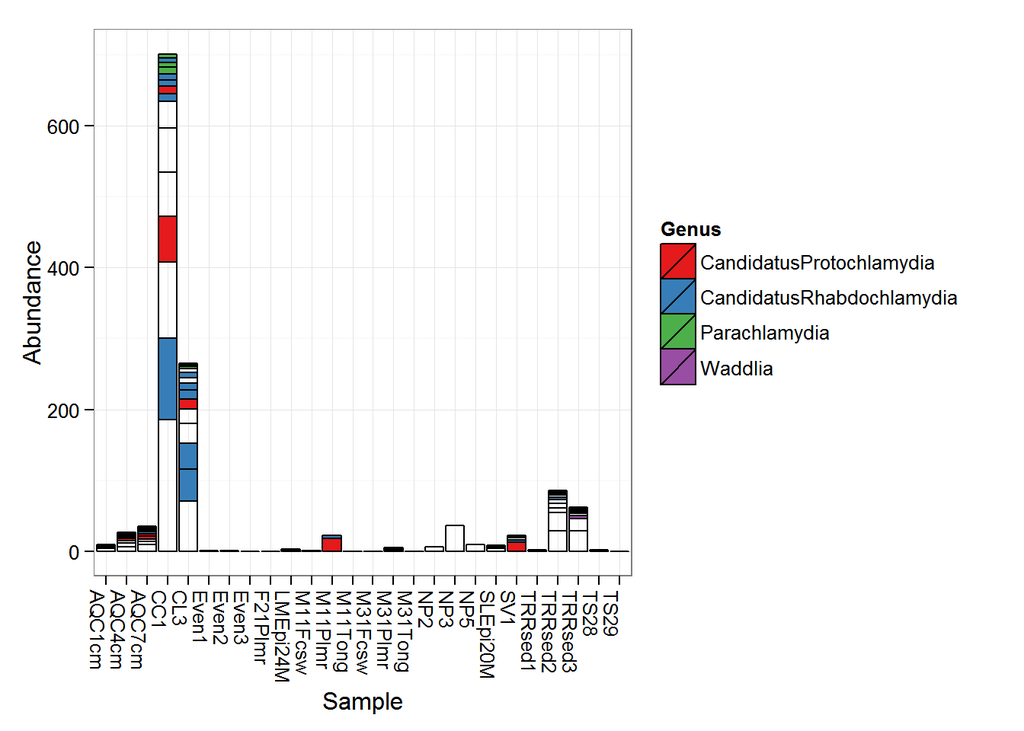

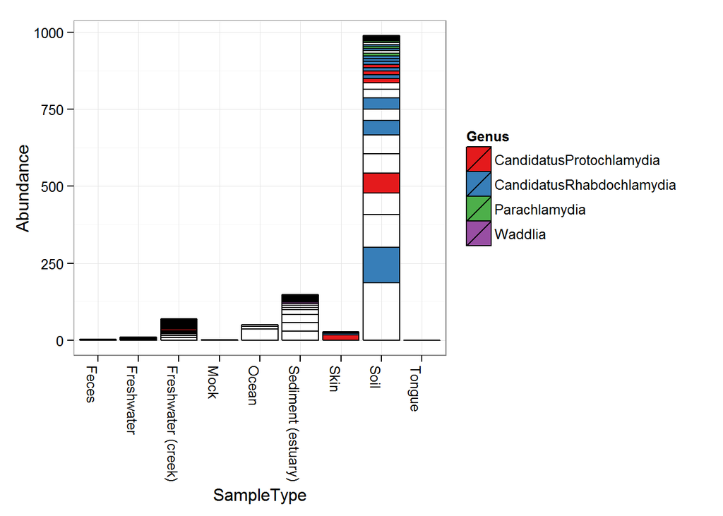

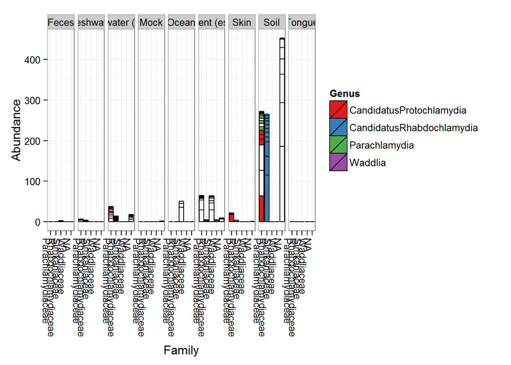

Lastly, I worked with heat maps to see if the data could be recreated using the [heat map tutorial](http://joey711.github.io/phyloseq/plot_heatmap-examples.html).

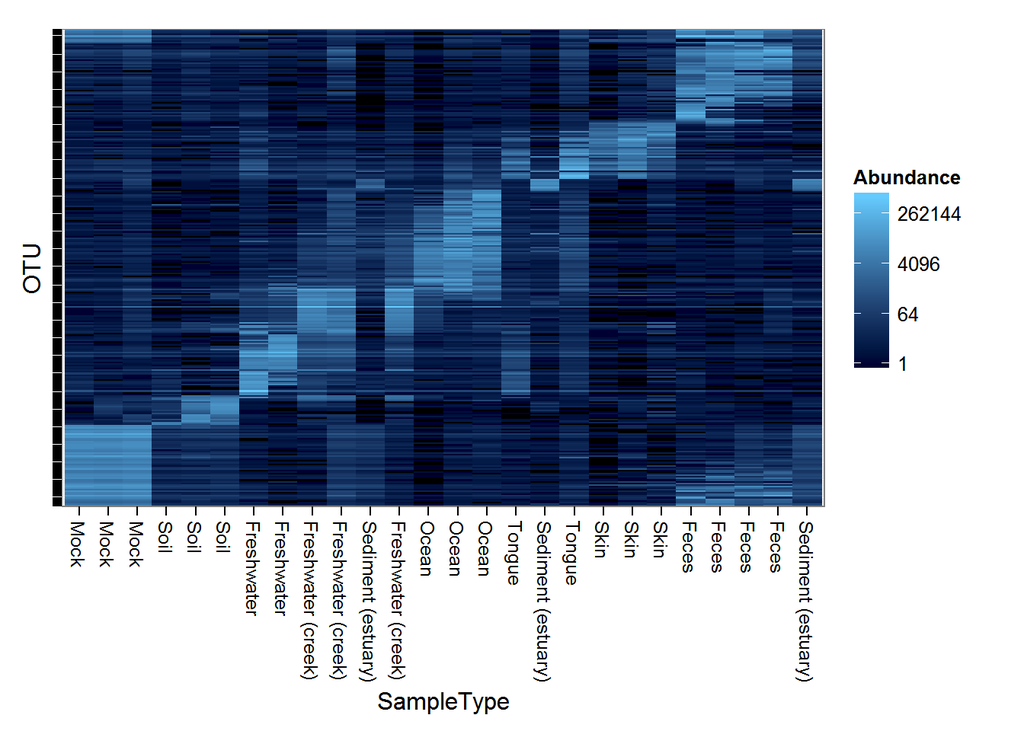

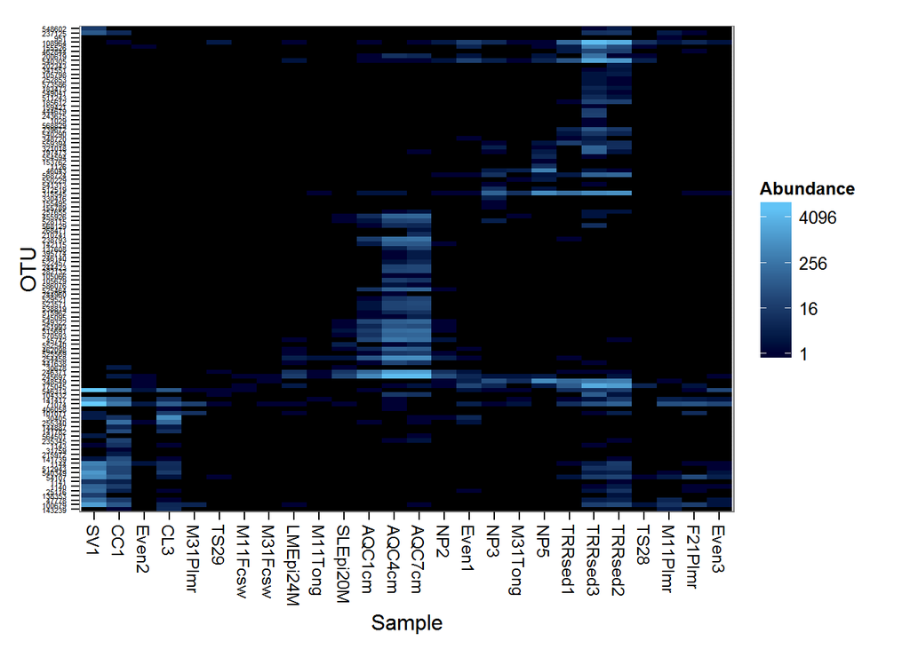

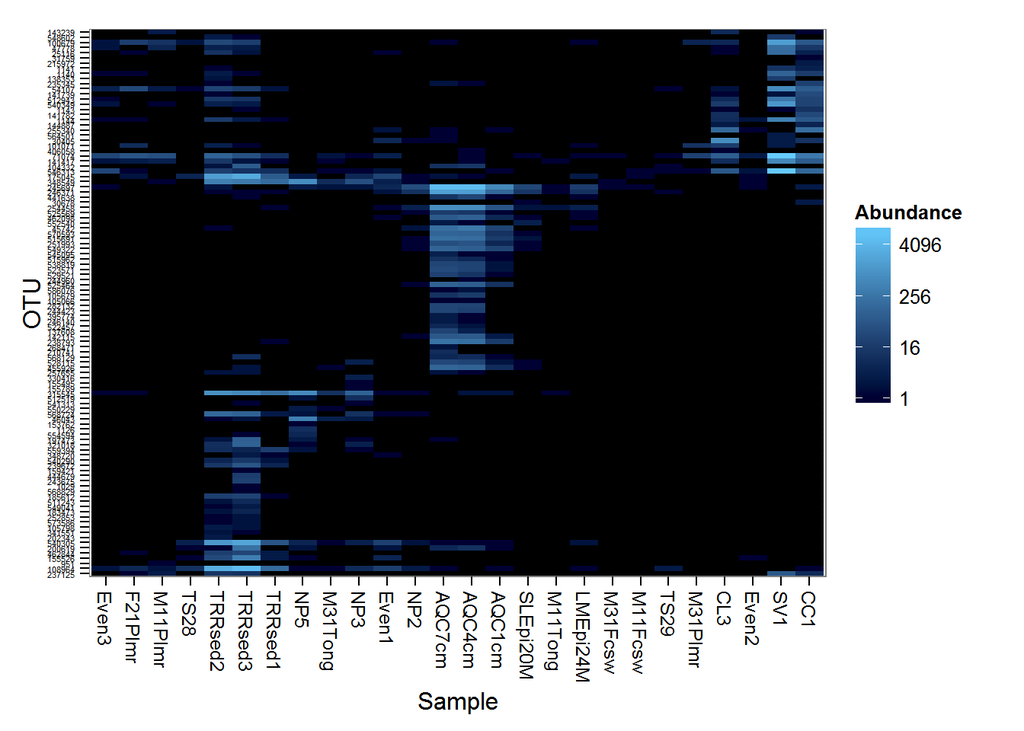

### Results

I was able to recreate most of the plots that were on the phyloseq tutorial website, and even created a few plots of my own. However, I had a lot of difficulty and errors with the ordination plots.

### Discussion

This project was based on reproducibility. I wanted to test if I could reproduce some of the tutorials on the phyloseq website, and hopefully expand upon the plots a little bit. I was initially hoping by doing so, I would become more familiar with the program and try again to make plots with my data. However, I do not feel the tutorial prepared me well enough to do so, just yet.

when I had problems reproducing the ordination plots, I became frustrated because I could not figure out how to fix the plots. For example, I had a pch error. In the code visible to me, pch was not there. Hence, this brings up an issue with reproducible data when using someone eles’s code. If all of the code is not visible, then it would be challenging to know what they did so you know how to fix it. It also makes it challenging to compare different versions of the code when the code is updated.

In the future, I want learn how to use phyloseq and use it to analyze my data. There are a lot of features to import data from Mothur and Qiime that seems to be really useful.